# Chapter 2 Homework

### Home price data

For this problem set, we will be using a subset of the Ames Housing Data that is introduced in Chapter 3 and used for examples involving lasso regularized regression. The data in `ames2009.csv` consist of observed home sales in Ames IA for 2009 and part of 2010.

**Calculate the standard error and 95% Confidence Interval for the mean unconditional sales price.**

```r
# read the data and calculate mean and sd
ames <- read.csv("Ames2009.csv", strings=T)
xbar <- mean(ames$SalePrice)
xsd <- sd(ames$SalePrice)

# standard error
( muse <- xsd/sqrt(nrow(ames)) )
```

```
[1] 2506.944
```

```r
# 95% CI
xbar + c(-1,1)*1.96*muse
```

```
[1] 173454.4 183281.6
```

**Regress the `log(SalePrice)` onto all variables except for `Neighborhood`. Which regression coefficients are significant when you control for a 5% false discovery rate.**

First fit the regression.

```r
amesfit <- glm(log(SalePrice) ~ .-Neighborhood, data=ames)
```

We can extract the p values and plot them.

```r
pvals <- summary(amesfit)$coef[-1,"Pr(>|t|)"]
length(pvals)
```

```
[1] 22
```

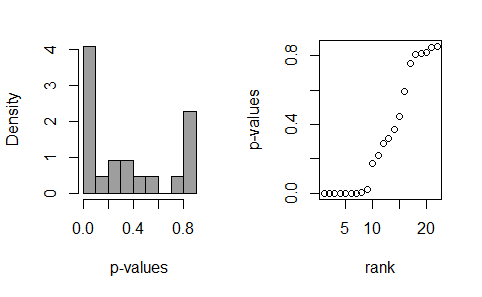

```r
par(mfrow=c(1,2))
hist(pvals, col=8, breaks=10, xlab="p-values", main="", freq=FALSE)
plot(sort(pvals), xlab="rank", ylab="p-values")
```

```r
fdr_cut <- function(pvals, q){
        pvals <- pvals[!is.na(pvals)]
        N <- length(pvals)
        k <- rank(pvals, ties.method="min")
        max(pvals[ pvals<= (q*k/N) ])
}
cutoff5 <- fdr_cut(pvals,q=.05)
print(cutoff5)
```

```
[1] 0.01959998
```

```r
which(pvals<=cutoff5)
```

```
 log.Lot.Area  Overall.Qual  Overall.Cond    Year.Built
            1            10            11            12
 Central.AirY   Gr.Liv.Area     Half.Bath Bedroom.AbvGr
           13            17            19            20
Kitchen.AbvGr
           21
```

**What is the 95% confidence interval for the effect of having Central Air on the expected log sale price? Use both the statistics from the fitted glm and a bootstrap to calculate and compare.**

First, from the glm object.

```r
( bstats <- summary(amesfit)$coef["Central.AirY",] )
```

```
    Estimate   Std. Error      t value     Pr(>|t|)
1.321356e-01 2.417973e-02 5.464727e+00 5.900662e-08
```

```r
bstats["Estimate"] + c(-1,1)*1.96*bstats["Std. Error"]
```

```
[1] 0.08474337 0.17952792
```

Now, using the bootstrap. We’ll use the percentile bootstrap CI here without any bias correction. Note the seed is set equal to one.

```r
# write a function to extract coefficients from a bootstrap fit
getBeta <- function(data, obs, var){
    fit <- glm(log(SalePrice) ~ .-Neighborhood, data=data[obs,])
    return(fit$coef[var])
}

library(parallel)
library(boot)
set.seed(1)
( betaBoot <- boot(ames, getBeta, 2000, var="Central.AirY",
                 parallel="snow", ncpus=detectCores()) )
```

[output not shown]

The bootstrap interval is much wider (due to a SE of 0.04 vs 0.02 for the standard method).

**Obtain a 95% CI coefficient on Central Air while allowing for dependence in sales prices within neighborhoods.**

We can do this with a block bootstrap.

```r
byNBHD <- split(ames, ames$Neighborhood)
set.seed(1)
getBetaBlock <- function(data, ids, var){
    data <- do.call("rbind",data[ids])
    fit <- glm(log(SalePrice) ~ .-Neighborhood, data=data)
    return(fit$coef[var])
}
( betaBootB <- boot(byNBHD, getBetaBlock, 2000, var="Central.AirY",
                          parallel="snow", ncpus=detectCores()) )
```

[output not shown]

Or, you can use the sandwich package.

```r
library(sandwich)
library(lmtest)
Vblock <- vcovCL(amesfit, cluster=ames$Neighborhood)
clstats <- coeftest(amesfit, vcov = Vblock)["Central.AirY",]
round(clstats, 5)
```

```
  Estimate Std. Error    z value   Pr(>|z|)
   0.13214    0.04153    3.18157    0.00146
```

```r
clstats["Estimate"] + c(-1,1)*1.96*clstats["Std. Error"]
```

```
[1] 0.05073362 0.21353766
```

The clustered standard error estimates from Sandwich are pretty close to the bootstrap results.

This multiplicative effect is the exponentiated coefficient. The exponentiation is a nonlinear transformation, and the distribution of this transformation will not be equal to the transformation of the raw coefficient distribution (i.e., exp(beta.hat) is a biased estimate for true exp(beta)). So we should use the bias corrected bootstrap to obtain the 95% CI.

```r
quantile(2*exp(betaBootB$t0) - exp(betaBootB$t), c(.025, .975))
```

```
    2.5%    97.5%
1.057383 1.260307
```